# Environmental variables plots

This code was written by II for the manuscript: https://doi.org/10.1093/icesjms/fsae129 This code is preceded by “Analysis 2.Rmd” and is the final script of this project.

# Objective of code:

In this final .Rmd we are interested in plotting our study region, calculating summary stats about our acoustic tracks and plotting the location various ctd data

- bathymetry map of acoustic tracks (where did we sample?)
- each oceanographic variable plotted per year

# Background

We would like to have a plot showing the larger study are for reference as well as the oceanographic variables we sampled over this region

# Study area– Map of acoustic tracks

# Add bathymetry

Using marmap package, load NOAA bathymetry data NOTE: these data are also loaded in Read Clean.Rmd

```r
library(marmap) # package for loading bathy data
# select for our region
range(echo_integration_all$Lat_M) #36 to 38.5
```

```
[1] 36.41916 38.40258
```

```r
range(echo_integration_all$Lon_M) # -125 to -121
```

```
[1] -124.1786 -121.9662
```

```r
bathy <- getNOAA.bathy(lon1 = -125, lon2 = -121,
lat1 = 35, lat2 = 40, resolution = 1)
```

```
Querying NOAA database ...
This may take seconds to minutes, depending on grid size

==================================================

Building bathy matrix ...
```

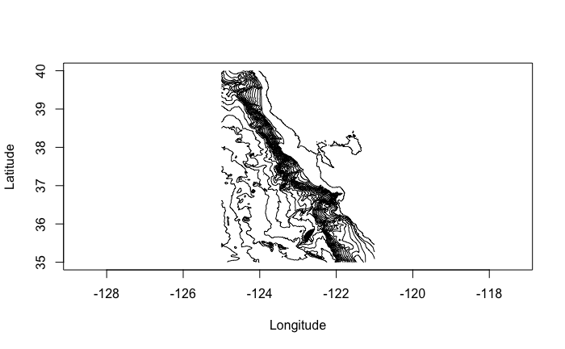

```r
?getNOAA.bathy # for documentation

plot(bathy)
```

```r
#convert to xyz data
bathy_xyz <- as.xyz(bathy)

#select for only ocean depths (avoid land) but while keeping V1 and V2
baty_xyz= bathy_xyz |>
  filter(V3<=0) # land values are positive while ocean are negative so select for only negative values

##convert to dataframe for ggplot
#bathy_xyz_fortify= fortify(bathy_xyz)
```

# Mean depth

overall mean depth of sampled area

```r
bathy_acoustic_track |>
  summarise(mean_depth=mean(depth))
```

| mean_depth |
| --- |
| -1743.218 |

# PLOT acoustic tracks with underlying bathymetry data

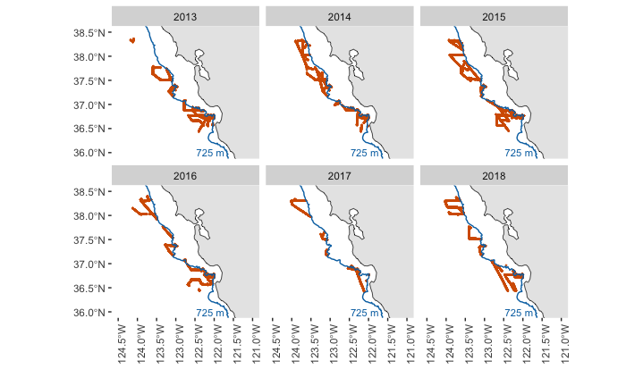

```r
ggplot(data=bathy_xyz)+
  #geom_contour(data=bathy_xyz, aes(x=V1, y=V2, z=V3), breaks = c(-200, -1000, -3000, -4000), color="#56B4E9" , linewidth=0.09)+ #Depth breaks
  annotate(geom="text", x=-122.1, y=36, label="725 m", color="#0072B2", size=3)+ #label contour
  geom_point(data= echo_integration_all, aes(x=Lon_M, y=Lat_M), shape=21, size=0.20, color=  "#D55E00" , alpha=0.65)+ #add acoustic track location info
  geom_sf(data=states, fill= "#999999" , alpha=0.25, color="black", lwd=0.25)+ #state outline
  coord_sf(xlim=c(-124.5, -121 ), ylim=c(36 ,38.5))+ #study region "core" area
  geom_contour(data=bathy_xyz, aes(x=V1, y=V2, z=V3), breaks = c(-725), color="#0072B2", size=0.5)+ # depth minimum value of 725m
  xlab("")+
  ylab("")+
  theme(axis.text.x  = element_text(angle=90),
        panel.grid = element_blank(),
        panel.background = element_rect(fill="white"))+
  facet_wrap(~year)
```

```r
#ggsave("./plots/coverage.pdf", dpi=300) #pdf
```

# Basemaps

```r
library("sf")
library("rnaturalearth")
library("rnaturalearthdata")


coast <- rnaturalearth::ne_coastline(scale = "medium", returnclass = "sf")
countries <- rnaturalearth::ne_countries(scale = "medium", returnclass = "sf")
states <- rnaturalearth::ne_states(returnclass = "sf")
?ne_states()

# to view
ggplot() +
  geom_sf(data= coast)
```

# Plot: zoomed out study area

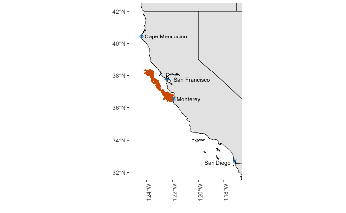

```r
ggplot()+
  geom_sf(data=states, fill= "#999999" , alpha=0.25, color="black", lwd=0.25)+
  geom_point(data= echo_integration_all, aes(x=Lon_M, y=Lat_M), shape=21, size=0.20, color= "#D55E00" , alpha=0.65)+ #add acoustic track location info
  annotate(geom="text", x=-120.5, y=37.75, label="San Francisco", color="black", size=3)+ # sf
  annotate(geom="point", x=-122.44, y=37.75, color="#0072B2", size=2, shape=8)+
  annotate(geom="text", x=-120.75, y=36.55, label="Monterey", color="black", size=3)+
  annotate(geom="point", x=-121.89, y=36.55, color="#0072B2", size=2, shape=8)+
  annotate(geom="text", x=-122.5, y=40.44, label="Cape Mendocino", color="black", size=3)+
  annotate(geom="point", x=-124.4, y=40.44, color="#0072B2", size=2, shape=8)+
  annotate(geom="text", x=-118.5, y=32.6, label="San Diego", color="black", size=3)+
  annotate(geom="point", x=-117.16, y=32.7, color="#0072B2", size=2, shape=8)+
  coord_sf(xlim=c(-125, -117 ), ylim=c(32 ,42))+ #study region "core" area
  xlab("")+
  ylab("")+
  theme(axis.text.x  = element_text(angle=90),
        panel.grid = element_blank(),
        panel.background = element_rect(fill="white"))

# save output
ggsave("./plots/analysis 2/coverage_wide.png",dpi=300) #pdf
```

# Start and end date of acoustic tracks per year

```r
echo_integration_all |>
  group_by(year) |>
  reframe(time_range=range(time)) #start and end dates per year
```

[output not shown]

# CTD date range

[output not shown]

# PLOT of grid cells with acoustic track and CTD position overlaid

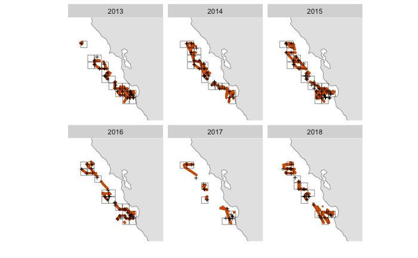

```r
# Plot grid cells with acoustic tracks and ctd cast locations
ggplot()+
  geom_sf(data=states)+ # add a basemap
  coord_sf(xlim=c(-124.5, -121 ), ylim=c(36 ,39))+ #study region
  geom_point(data=echo_integration_all, aes(x=Lon_M, y=Lat_M), color="#D55E00" , size=0.55, alpha=0.50)+ #cells with at least 3 fine resolution cells
  geom_point(data=ctd_deep_loc_core, aes(x=LONGITUDE, y=LATITUDE), shape=3, size=1,color="black", stroke=0.5)+ # all ctd locations
  geom_point(data=acoustics_ctd, aes(x=lon, y=lat), size=4, shape=22, color="black" , stroke=0.50, alpha=0.5)+  # grid cell
  labs(fill="Center of mass [m]")+#change legend title
  #scale_x_continuous(breaks = lon, minor_breaks = NULL)+ #note skipping lines now because not min, max
  #scale_y_continuous(breaks=lat, minor_breaks = NULL)+
  theme(axis.text.x = element_blank(),
        axis.text.y = element_blank(),
        axis.ticks = element_blank(), #tick marks from lat long coordinates
        #panel.grid = element_line(colour = "grey", linetype = "solid", linewidth =0.05),# removed gridlines but could readd here
        panel.background = element_blank())+
  labs(x="", y="")+
  facet_wrap(~year)

ggsave(filename = "./plots/analysis 2/coverage_grid_ctd.pdf")
```

```r
#ggsave(filename = "./plots/analysis 2/coverage_grid_ctd.png", dpi=300) #png
```

# Plot grid cells with acoustics + ocean variables

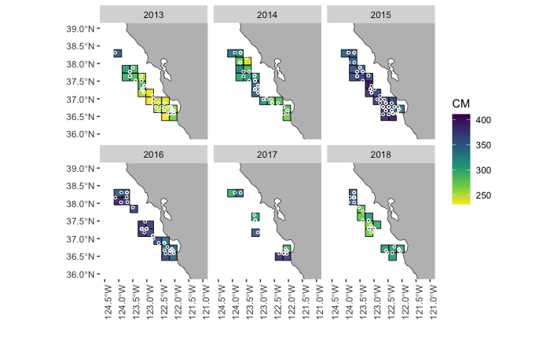

```r
{ggplot()+
  geom_sf(data=states, fill="gray", color="black")+
  coord_sf(xlim=c(-124.5, -121 ), ylim=c(36 ,39))+ #study region
  geom_point(data=acoustics_ctd, aes(x=lon, y=lat, fill=cm_m), shape=22, size=3.5, alpha=0.9)+ # cells
  scale_fill_viridis_c(direction=-1)+ # scale center of mass depth
  geom_point(data=ctd_deep_loc_core, aes(x=LONGITUDE, y=LATITUDE), shape=1, size=1,color="white", stroke=0.5)+ # all ctd locations
  labs(x="", y="", fill="CM")+
  theme(axis.text.x  = element_text(angle=90),
        panel.grid = element_blank(),
        panel.background = element_rect(fill="white"))+
  facet_wrap(~year)}

ggsave(file="./plots/analysis 2/ctd_grid.pdf")
```

```r
NA
```

# Oceanographic variables between years

# Calculate mean values

| year | median_cm | mean_cm | median_dyn_ht | mean_dyn_ht | median_MVBS | mean_MVBS | median_temp_10m | mean_temp_10m | median_temp_175m | mean_temp_175m | median_Z | mean_Z | median_o2_175m | mean_o2_175m | median_o2_500m | mean_o2_500m | median_chl | mean_chl | n |
| --- | --- | --- | --- | --- | --- | --- | --- | --- | --- | --- | --- | --- | --- | --- | --- | --- | --- | --- | --- |
| 2013 | 252.1668 | 266.7294 | -0.06000 | -0.053823529 | -72.14327 | -72.38134 | 11.91267 | 11.62282 | 8.395000 | 8.328718 | 21.59091 | 29.27746 | 1.712500 | 1.913757 | 0.3650000 | 0.3656303 | 83.260 | 100.23412 | 17 |
| 2014 | 306.7734 | 302.8225 | -0.02835 | -0.026187500 | -72.28975 | -72.46582 | 11.92700 | 12.04996 | 8.562500 | 8.460073 | 37.33252 | 35.80512 | 1.782500 | 1.801063 | 0.3866667 | 0.3903333 | 114.460 | 161.31813 | 16 |
| 2015 | 365.6807 | 369.7454 | -0.01000 | -0.006221053 | -66.77516 | -66.59695 | 12.97867 | 12.92451 | 8.500000 | 8.523717 | 57.22788 | 54.79611 | 2.087500 | 2.040855 | 0.4033333 | 0.4074424 | 86.920 | 88.84158 | 19 |
| 2016 | 365.4778 | 364.5834 | 0.05000 | 0.055280000 | -68.24107 | -68.67728 | 12.79357 | 12.70177 | 8.335000 | 8.290125 | 54.08125 | 53.41700 | 2.027500 | 2.122792 | 0.3925000 | 0.3945000 | 52.470 | 59.78800 | 15 |
| 2017 | 341.0123 | 333.1694 | -0.01000 | 0.001914286 | -71.02887 | -71.41505 | 11.79400 | 11.82180 | 8.363333 | 8.357857 | 39.36883 | 39.56057 | 1.853333 | 1.870952 | 0.4100000 | 0.3909524 | 45.640 | 92.50000 | 7 |
| 2018 | 301.4485 | 300.3273 | -0.03750 | -0.022608333 | -72.03165 | -71.67123 | 12.48563 | 12.41574 | 8.233750 | 8.318250 | 30.04690 | 33.61777 | 1.760833 | 1.795222 | 0.3775000 | 0.3957500 | 51.575 | 60.77583 | 12 |

# Dynamic height between years

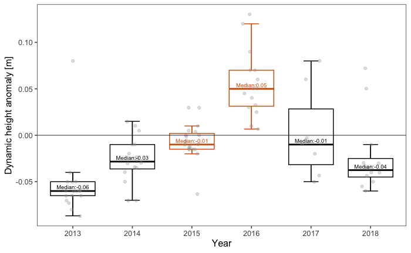

```r
ggplot(data=acoustics_ctd, aes(x=as.factor(year), y=dyn_ht_500m, group=year, color=as.factor(year)))+
  stat_boxplot(geom="errorbar", width=0.25)+
  geom_boxplot( aes(group=year), outlier.shape=NA, show.legend = FALSE)+ #plot boxplots without outliers since in jitter
  scale_color_manual(values = c("2013"="black" , "2014"="black", "2015"="#D55E00" , "2016"= "#D55E00" , "2017"="black", "2018"="black"))+
  geom_jitter(alpha=0.3, color="#999999" , width=0.15)+ #add actual data points to our boxplot
  geom_text(data= summary_yrs, aes(x = year, y = median_dyn_ht, label = paste0("Median:", round(median_dyn_ht, 2))), size = 2.5, vjust = -0.5)+ #label median
  #geom_text(data= summary_yrs, aes(x =year, y = median_dyn_ht, label = paste0("n: ", n)), size = 3, vjust = 1.5, color="black")+ #label sample size
  geom_hline(yintercept=0, linewidth=0.5, color="black", alpha=0.6)+ # 0 intercept
  xlab("Year")+
  ylab("Dynamic height anomaly [m]")+
  ggthemes::theme_few()+
  theme(legend.position = 'none')

ggsave(filename = "./plots/analysis 2/oceano/box_dyn_ht.pdf", width=170, height= 100,units="mm", dpi=300)
```